# PRACTICAL MACHINE LEARNING PROJECT: “PREDICTING HUMAN EXERCISE USING SELF-MONITORING DEVICES”

Pilar Cantero

19 de septiembre de 2016

## EXECUTIVE SUMMARY

The emergence of the digital age has been impacted with several technological changes where people are willing to measure their own individual daily activities related to work, exercise, sleep, diet, mood, etc. We are covering ourselves up with these new “gadgets”, such as Fitbit, Jawbone Up and Nike FuelBand, which are collecting all this information. These type of devices are part of the quantified self movement and one thing that people regularly do is quantify how much of a particular activity they do, but they rarely quantify how well they do it.

In our analysis we carried out an experiment with a group of 6 participants (aged between 20-28 years) using data from accelerometers on the belt, forearm, arm and dumbbell, to build a model to predict the manner in which these participants did the exercise, and then to predict the movement of 20 different test cases.

They were asked to perform barbell lifts correctly and incorrectly in 5 different ways: exactly according to the specification (Class A), throwing the elbows to the front (Class B), lifting the dumbbell only halfway (Class C), lowering the dumbbell only halfway (Class D) and throwing the hips to the front (Class E). Class A corresponds to the specified execution of the exercise, while the other 4 classes correspond to common mistakes.

More information is available from the website here: http://groupware.les.inf.puc-rio.br/har (see the section on the Weight Lifting Exercise Dataset).

Thus, it is an interesting problem to build a model that predicts what kind of exercise a subject is performing based on the quantitative measurements from self monitoring devices.

Our analysis suggests that our prediction function, developed using the Random Forests method, will have a great accuracy (over 99.70%) to predict the 20 test cases with 100% accuracy.

## BASIC SETTING

RStudio

knitr

echo = TRUE

set.seed(12345)

Load libraries:

library(caret) library(rpart) library(rpart.plot) library(rattle) library(RColorBrewer) library(randomForest) library(“e1071”) library(gbm) library(ggplot2) library(gridExtra).

## GETTING AND CLEANING DATA

The data for this project come from this original source: http://groupware.les.inf.puc-rio.br/har

Velloso, E.; Bulling, A.; Gellersen, H.; Ugulino, W.; Fuks, H. Qualitative Activity Recognition of Weight Lifting Exercises. Proceedings of 4th International Conference in Cooperation with SIGCHI (Augmented Human ’13) . Stuttgart, Germany: ACM SIGCHI, 2013.

I would like to thank the authors for being very generous in allowing their data to be used for this kind of assignment.

The training data for this project are available here: https://d396qusza40orc.cloudfront.net/predmachlearn/pml-training.csv

The test data are available here: https://d396qusza40orc.cloudfront.net/predmachlearn/pml-testing.csv

### Downloading and reading the data:

```r
trainurl <- "http://d396qusza40orc.cloudfront.net/predmachlearn/pml-training.csv"
traindata <- read.csv(url(trainurl), na.strings=c("NA","#DIV/0!",""))
dim(traindata)
```

```
## [1] 19622   160
```

```r
testurl <- "http://d396qusza40orc.cloudfront.net/predmachlearn/pml-testing.csv"
validationdata <- read.csv(url(testurl), na.strings=c("NA","#DIV/0!",""))
dim(validationdata)
```

```
## [1]  20 160
```

### Getting a subtraining data set and a subtesting data set from the original training data set to be used for Cross Validation:

Dividing the original traindata set into two subdata sets: 60% in the finaltrain data set and 40% in the finaltest data set. I will perform cross validation within the training division in order to improve the model fit. After that, I will do out-of-sample test with the testing division to validate the model where an expected out-of-sample error rate of less than 0.5%, or 99.5% accuracy, would be acceptable before it is used to perform the prediction on the 20 test cases (that must have 100% accuracy to obtain 20 points awarded). Therefore, I leave the original test set (validationdata) alone, and I will apply our ultimate prediction algorithm to this test set in order to be an unbiased measurement.

```r
library (caret)
subtrain <- createDataPartition(traindata$classe, p=0.6, list=FALSE)
finaltrain <- traindata[subtrain, ]
finaltest<- traindata[-subtrain, ]
dim(finaltrain)
```

```
## [1] 11776   160
```

```r
dim(finaltest)
```

```
## [1] 7846  160
```

### Cleaning data

I will have a look at these subdata sets and I will call the nearZeroVar function with the argument saveMetrics = TRUE

```r
x = nearZeroVar(finaltrain, saveMetrics = TRUE)
 str(x, vec.len=2)
```

```
## 'data.frame':    160 obs. of  4 variables:
##  $ freqRatio    : num  1 1.11 ...
##  $ percentUnique: num  100 0.051 ...
##  $ zeroVar      : logi  FALSE FALSE FALSE ...
##  $ nzv          : logi  FALSE FALSE FALSE ...
```

```r
y = nearZeroVar(finaltest, saveMetrics = TRUE)
str(y, vec.len=2)
```

```
## 'data.frame':    160 obs. of  4 variables:
##  $ freqRatio    : num  1 1.09 ...
##  $ percentUnique: num  100 0.0765 ...
##  $ zeroVar      : logi  FALSE FALSE FALSE ...
##  $ nzv          : logi  FALSE FALSE FALSE ...
```

By default, a predictor is classified as near-zero variance if the percentage of unique values in the samples is less than 10% and when the frequency ratio mentioned above is greater than 19 (95/5).

We can explore which ones are the zero variance predictors:

```r
x[x[,"zeroVar"] > 0, ]
```

```
##                        freqRatio percentUnique zeroVar  nzv
## kurtosis_yaw_belt              0   0.000000000    TRUE TRUE
## skewness_yaw_belt              0   0.000000000    TRUE TRUE
## amplitude_yaw_belt             0   0.008491848    TRUE TRUE
## kurtosis_yaw_dumbbell          0   0.000000000    TRUE TRUE
## skewness_yaw_dumbbell          0   0.000000000    TRUE TRUE
## amplitude_yaw_dumbbell         0   0.008491848    TRUE TRUE
## kurtosis_yaw_forearm           0   0.000000000    TRUE TRUE
## skewness_yaw_forearm           0   0.000000000    TRUE TRUE
## amplitude_yaw_forearm          0   0.008491848    TRUE TRUE
```

```r
y[y[,"zeroVar"] > 0, ]
```

```
##                        freqRatio percentUnique zeroVar  nzv
## kurtosis_yaw_belt              0    0.00000000    TRUE TRUE
## skewness_yaw_belt              0    0.00000000    TRUE TRUE
## amplitude_yaw_belt             0    0.01274535    TRUE TRUE
## kurtosis_yaw_dumbbell          0    0.00000000    TRUE TRUE
## skewness_yaw_dumbbell          0    0.00000000    TRUE TRUE
## amplitude_yaw_dumbbell         0    0.01274535    TRUE TRUE
## kurtosis_yaw_forearm           0    0.00000000    TRUE TRUE
## skewness_yaw_forearm           0    0.00000000    TRUE TRUE
## amplitude_yaw_forearm          0    0.01274535    TRUE TRUE
```

and which ones are the near-zero variance predictors:

```r
x[x[,"zeroVar"] + x[,"nzv"] > 0, ]
```

```
##                        freqRatio percentUnique zeroVar  nzv
## new_window              45.18039   0.016983696   FALSE TRUE
## kurtosis_yaw_belt        0.00000   0.000000000    TRUE TRUE
## skewness_yaw_belt        0.00000   0.000000000    TRUE TRUE
## amplitude_yaw_belt       0.00000   0.008491848    TRUE TRUE
## avg_roll_arm            50.00000   1.749320652   FALSE TRUE
## stddev_roll_arm         50.00000   1.749320652   FALSE TRUE
## var_roll_arm            50.00000   1.749320652   FALSE TRUE
## avg_pitch_arm           50.00000   1.749320652   FALSE TRUE
## stddev_pitch_arm        50.00000   1.749320652   FALSE TRUE
## var_pitch_arm           50.00000   1.749320652   FALSE TRUE
## avg_yaw_arm             50.00000   1.749320652   FALSE TRUE
## stddev_yaw_arm          52.00000   1.732336957   FALSE TRUE
## var_yaw_arm             52.00000   1.732336957   FALSE TRUE
## amplitude_roll_arm      25.00000   1.672894022   FALSE TRUE
## kurtosis_yaw_dumbbell    0.00000   0.000000000    TRUE TRUE
## skewness_yaw_dumbbell    0.00000   0.000000000    TRUE TRUE
## amplitude_yaw_dumbbell   0.00000   0.008491848    TRUE TRUE
## kurtosis_yaw_forearm     0.00000   0.000000000    TRUE TRUE
## skewness_yaw_forearm     0.00000   0.000000000    TRUE TRUE
## amplitude_yaw_forearm    0.00000   0.008491848    TRUE TRUE
## avg_roll_forearm        25.50000   1.732336957   FALSE TRUE
## stddev_roll_forearm     53.00000   1.723845109   FALSE TRUE
## var_roll_forearm        53.00000   1.723845109   FALSE TRUE
## avg_pitch_forearm       51.00000   1.740828804   FALSE TRUE
## stddev_pitch_forearm    51.00000   1.740828804   FALSE TRUE
## var_pitch_forearm       51.00000   1.740828804   FALSE TRUE
## avg_yaw_forearm         51.00000   1.740828804   FALSE TRUE
## stddev_yaw_forearm      52.00000   1.732336957   FALSE TRUE
## var_yaw_forearm         52.00000   1.732336957   FALSE TRUE
```

```r
y[y[,"zeroVar"] + y[,"nzv"] > 0, ]
```

```
##                        freqRatio percentUnique zeroVar  nzv
## new_window              50.96026    0.02549070   FALSE TRUE
## kurtosis_yaw_belt        0.00000    0.00000000    TRUE TRUE
## skewness_yaw_belt        0.00000    0.00000000    TRUE TRUE
## amplitude_yaw_belt       0.00000    0.01274535    TRUE TRUE
## avg_roll_arm            27.00000    1.59316849   FALSE TRUE
## stddev_roll_arm         27.00000    1.59316849   FALSE TRUE
## var_roll_arm            27.00000    1.59316849   FALSE TRUE
## avg_pitch_arm           27.00000    1.59316849   FALSE TRUE
## stddev_pitch_arm        27.00000    1.59316849   FALSE TRUE
## var_pitch_arm           27.00000    1.59316849   FALSE TRUE
## avg_yaw_arm             27.00000    1.59316849   FALSE TRUE
## stddev_yaw_arm          28.00000    1.58042315   FALSE TRUE
## var_yaw_arm             28.00000    1.58042315   FALSE TRUE
## kurtosis_yaw_dumbbell    0.00000    0.00000000    TRUE TRUE
## skewness_yaw_dumbbell    0.00000    0.00000000    TRUE TRUE
## amplitude_yaw_dumbbell   0.00000    0.01274535    TRUE TRUE
## kurtosis_yaw_forearm     0.00000    0.00000000    TRUE TRUE
## skewness_yaw_forearm     0.00000    0.00000000    TRUE TRUE
## amplitude_yaw_forearm    0.00000    0.01274535    TRUE TRUE
## avg_roll_forearm        32.00000    1.52944175   FALSE TRUE
## stddev_roll_forearm     34.00000    1.50395106   FALSE TRUE
## var_roll_forearm        34.00000    1.50395106   FALSE TRUE
## avg_pitch_forearm       32.00000    1.52944175   FALSE TRUE
## stddev_pitch_forearm    32.00000    1.52944175   FALSE TRUE
## var_pitch_forearm       32.00000    1.52944175   FALSE TRUE
## avg_yaw_forearm         32.00000    1.52944175   FALSE TRUE
## stddev_yaw_forearm      33.00000    1.51669641   FALSE TRUE
## var_yaw_forearm         33.00000    1.51669641   FALSE TRUE
```

#### 1.- I will remove variables with nzv:

```r
finalnzvtrain <-finaltrain[, -nearZeroVar(finaltrain)]
dim(finalnzvtrain)
```

```
## [1] 11776   131
```

```r
finalnzvtest <-finaltest[, -nearZeroVar(finaltest)]
dim(finalnzvtest)
```

```
## [1] 7846  132
```

#### 2.- In both data sets (finalnzvtrain and finalnzvtest) there are a lot of NA´s. I will remove variables that are mostly NA´s:

```r
trainNA <- sapply(finalnzvtrain, function(x) mean(is.na(x))) > 0.95
NoNAtrain <-finalnzvtrain[, trainNA==FALSE]
dim(NoNAtrain)
```

```
## [1] 11776    59
```

```r
testNA <- sapply(finalnzvtest, function(x) mean(is.na(x))) > 0.95
NoNAtest <-finalnzvtest[, testNA==FALSE]
dim(NoNAtest)
```

```
## [1] 7846   59
```

#### 3.- Having a look at the NoNAtrain and NoNAtest names, I will remove the columns (1:5) which seems to be identification variables.

```r
trainclean<-NoNAtrain[, -(1:5)]
testclean<-NoNAtest[, -(1:5)]
dim(trainclean)
```

```
## [1] 11776    54
```

```r
dim(testclean)
```

```
## [1] 7846   54
```

After performing the cleaning data process, we got two data subsets of 54 variables each.

#### 4.- Processing validationdata and testclean data sets:

```r
clean1 <- colnames(trainclean)
clean2 <- colnames(trainclean[, -54])  # remove the classe column
testclean2 <- testclean[clean1]       # allow only variables in testclean that are                                                 #also in trainclean
validation2 <- validationdata[clean2]   # allow only variables in validationdata that are also in trainclean
```

```r
dim(testclean2)
```

```
## [1] 7846   54
```

```r
dim(validation2)
```

```
## [1] 20 53
```

#### 5.- Coerce the data into the same type:

```r
for (i in 1:length(validation2) ) {
    for(p in 1:length(trainclean)) {
        if( length( grep(names(trainclean[i]), names(validation2)[p]) ) == 1)  {
            class(validation2[p]) <- class(trainclean[i])
        }
    }
}
```

#### 6.- Getting the same class between validation2 and trainclean:

```r
validation3 <- rbind(trainclean[2, -54] , validation2)
validationf <- validation3[-1,]
```

## PREDICTION MODEL BUILDING

I will use three methods in the training data set (trainclean) to model the regressions and which one that is more accurate, I will apply to the testing set (validationf) and use it for the quiz prediction. These methods are: Decision Trees, Random Forests, and Generalized Boosted Model. Also, I will plot a Confusion Matrix to have a look at the accuracy of these models.

### 1.- PREDICTION WITH DECISION TREES

#### Fit the model:

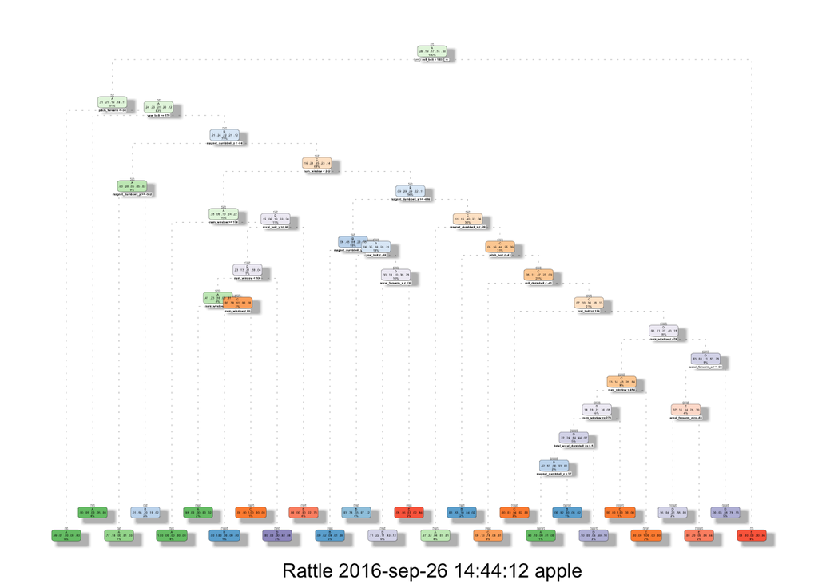

```r
set.seed(12345)
library(rpart)
library(rpart.plot)
library(rattle)
modDC <- rpart(classe ~ ., data=trainclean, method="class")
fancyRpartPlot(modDC)
```

#### Prediction on Test data set (testclean2):

```r
predictionDC <- predict(modDC, testclean2, type = "class")
confusionMatrix(predictionDC, testclean2$classe)
```

```
## Confusion Matrix and Statistics
##
##           Reference
## Prediction    A    B    C    D    E
##          A 2024  234   21   47   21
##          B   17  963   85   82   79
##          C    1   73 1107   35    4
##          D  142  198  141 1033  156
##          E   48   50   14   89 1182
##
## Overall Statistics
##
##                Accuracy : 0.8041
##                  95% CI : (0.7951, 0.8128)
##     No Information Rate : 0.2845
##     P-Value [Acc > NIR] : < 2.2e-16
##
##                   Kappa : 0.7521
##  Mcnemar's Test P-Value : < 2.2e-16
##
## Statistics by Class:
##
##                      Class: A Class: B Class: C Class: D Class: E
## Sensitivity            0.9068   0.6344   0.8092   0.8033   0.8197
## Specificity            0.9425   0.9584   0.9826   0.9029   0.9686
## Pos Pred Value         0.8624   0.7855   0.9074   0.6186   0.8547
## Neg Pred Value         0.9622   0.9162   0.9606   0.9590   0.9598
## Prevalence             0.2845   0.1935   0.1744   0.1639   0.1838
## Detection Rate         0.2580   0.1227   0.1411   0.1317   0.1507
## Detection Prevalence   0.2991   0.1563   0.1555   0.2128   0.1763
## Balanced Accuracy      0.9246   0.7964   0.8959   0.8531   0.8942
```

```r
conMatrixDC<-confusionMatrix(predictionDC, testclean2$classe)
```

#### PLOT MATRIX RESULTS:

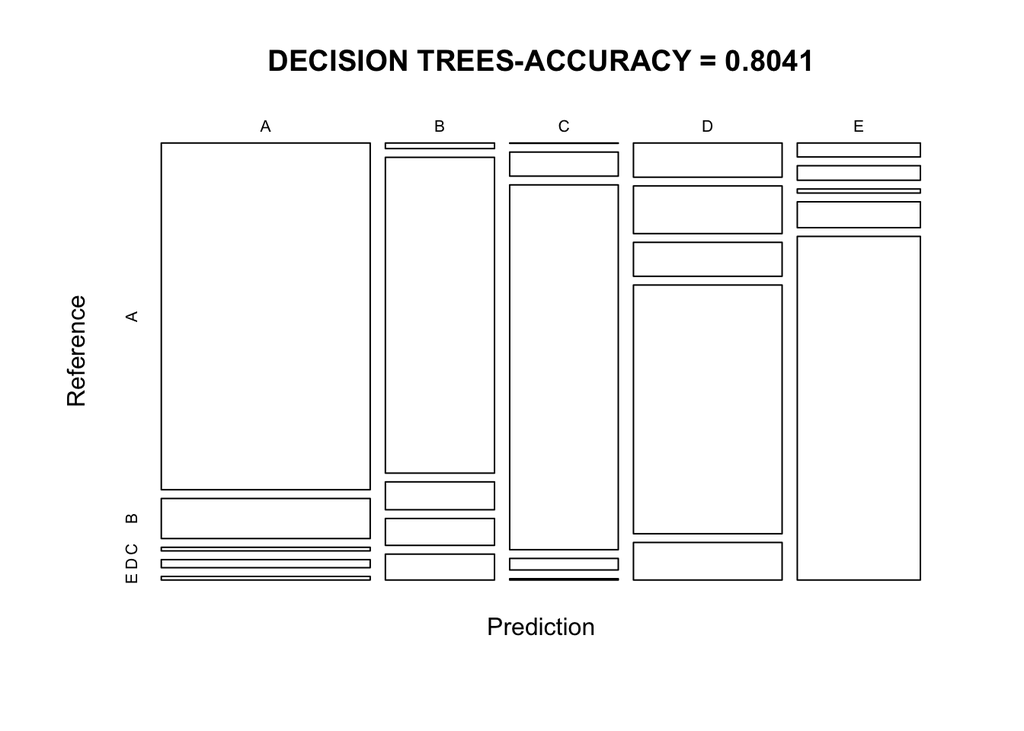

```r
plot(conMatrixDC$table, col = conMatrixDC$byClass,
     main = paste("DECISION TREES-ACCURACY =",
                  round(conMatrixDC$overall['Accuracy'], 4)))
```

### 2.-PREDICTION USING RANDOM FORESTS

#### Fit the model:

```r
set.seed(12345)
ctrRF <- trainControl(method="cv", number=3, verboseIter=FALSE)
modRF <- train(classe ~ ., data=trainclean, method="rf", trControl=ctrRF)
modRF$finalModel
```

```
##
## Call:
##  randomForest(x = x, y = y, mtry = param$mtry)
##                Type of random forest: classification
##                      Number of trees: 500
## No. of variables tried at each split: 27
##
##         OOB estimate of  error rate: 0.24%
## Confusion matrix:
##      A    B    C    D    E class.error
## A 3348    0    0    0    0 0.000000000
## B    6 2271    1    1    0 0.003510312
## C    0    6 2047    1    0 0.003407984
## D    0    1    7 1921    1 0.004663212
## E    0    0    0    4 2161 0.001847575
```

#### Prediction on Test data set (testclean2):

```r
predictionRF <- predict(modRF, newdata=testclean2)
confusionMatrix(predictionRF, testclean2$classe)
```

```
## Confusion Matrix and Statistics
##
##           Reference
## Prediction    A    B    C    D    E
##          A 2231    4    0    0    0
##          B    0 1511    2    0    0
##          C    0    3 1363    5    0
##          D    0    0    3 1281    2
##          E    1    0    0    0 1440
##
## Overall Statistics
##
##                Accuracy : 0.9975
##                  95% CI : (0.9961, 0.9984)
##     No Information Rate : 0.2845
##     P-Value [Acc > NIR] : < 2.2e-16
##
##                   Kappa : 0.9968
##  Mcnemar's Test P-Value : NA
##
## Statistics by Class:
##
##                      Class: A Class: B Class: C Class: D Class: E
## Sensitivity            0.9996   0.9954   0.9963   0.9961   0.9986
## Specificity            0.9993   0.9997   0.9988   0.9992   0.9998
## Pos Pred Value         0.9982   0.9987   0.9942   0.9961   0.9993
## Neg Pred Value         0.9998   0.9989   0.9992   0.9992   0.9997
## Prevalence             0.2845   0.1935   0.1744   0.1639   0.1838
## Detection Rate         0.2843   0.1926   0.1737   0.1633   0.1835
## Detection Prevalence   0.2849   0.1928   0.1747   0.1639   0.1837
## Balanced Accuracy      0.9994   0.9975   0.9976   0.9977   0.9992
```

```r
conMatrixRF <-confusionMatrix(predictionRF, testclean2$classe)
```

#### PLOT MATRIX RESULTS:

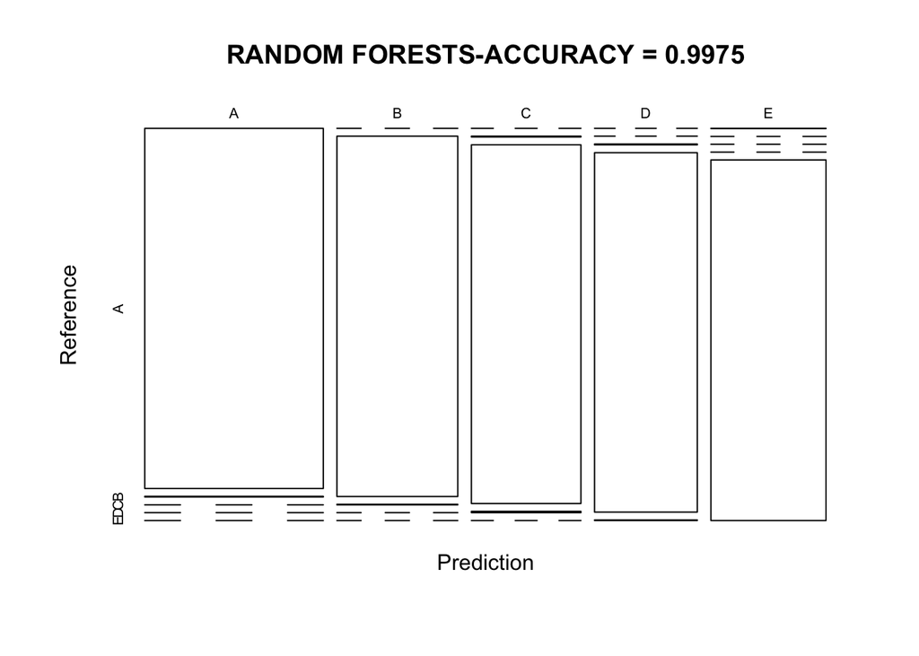

```r
plot(conMatrixRF$table, col = conMatrixRF$byClass,
     main = paste("RANDOM FORESTS-ACCURACY =",
                  round(conMatrixRF$overall['Accuracy'], 4)))
```

### 3.- PREDICTION USING GENERALIZED BOOSTED MODEL

#### Fit the model:

```r
set.seed(12345)
ctrGBM<- trainControl(method = "repeatedcv", number = 5, repeats = 1)
modGBM  <- train(classe ~ ., data=trainclean, method = "gbm",
                    trControl = ctrGBM, verbose = FALSE)
modGBM$finalModel
```

```
## A gradient boosted model with multinomial loss function.
## 150 iterations were performed.
## There were 53 predictors of which 42 had non-zero influence.
```

#### Prediction on Test data set (testclean2):

```r
predictionGBM <- predict(modGBM, newdata=testclean2)
confusionMatrix(predictionGBM, testclean2$classe)
```

```
## Confusion Matrix and Statistics
##
##           Reference
## Prediction    A    B    C    D    E
##          A 2220   11    0    2    0
##          B   12 1491    8    3    2
##          C    0   15 1356   13    1
##          D    0    1    3 1266    6
##          E    0    0    1    2 1433
##
## Overall Statistics
##
##                Accuracy : 0.9898
##                  95% CI : (0.9873, 0.9919)
##     No Information Rate : 0.2845
##     P-Value [Acc > NIR] : < 2.2e-16
##
##                   Kappa : 0.9871
##  Mcnemar's Test P-Value : NA
##
## Statistics by Class:
##
##                      Class: A Class: B Class: C Class: D Class: E
## Sensitivity            0.9946   0.9822   0.9912   0.9844   0.9938
## Specificity            0.9977   0.9960   0.9955   0.9985   0.9995
## Pos Pred Value         0.9942   0.9835   0.9791   0.9922   0.9979
## Neg Pred Value         0.9979   0.9957   0.9981   0.9970   0.9986
## Prevalence             0.2845   0.1935   0.1744   0.1639   0.1838
## Detection Rate         0.2829   0.1900   0.1728   0.1614   0.1826
## Detection Prevalence   0.2846   0.1932   0.1765   0.1626   0.1830
## Balanced Accuracy      0.9962   0.9891   0.9934   0.9915   0.9966
```

```r
conMatrixGBM <-confusionMatrix(predictionGBM, testclean2$classe)
```

#### PLOT MATRIX RESULTS:

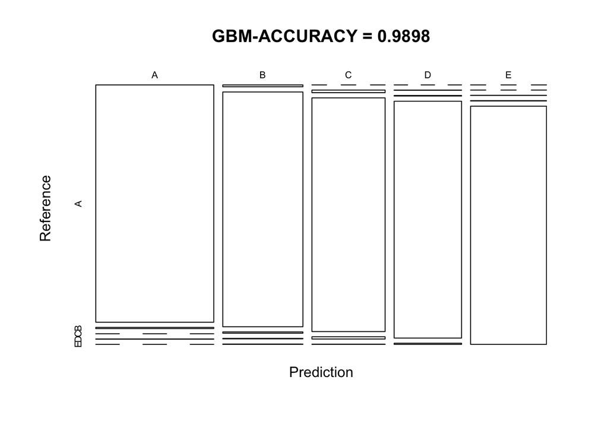

```r
plot(conMatrixGBM$table, col = conMatrixGBM$byClass,
     main = paste("GBM-ACCURACY =", round(conMatrixGBM$overall['Accuracy'], 4)))
```

## APPLYING THE SELECTED MODEL TO THE VALIDATION DATA

```r
AccuracyModels<-data.frame(Model=c("DC", "RF", "GBM"),
Accuracy = rbind(conMatrixDC$overall[1], conMatrixRF$overall[1], conMatrixGBM$overall[1]))
print(AccuracyModels)
```

```
##   Model  Accuracy
## 1    DC 0.8041040
## 2    RF 0.9974509
## 3   GBM 0.9898037
```

We can observe that Random Forest has a high accuracy (over 99.70%) and this is the higher of all of these models; cross validation is done with K=3 and the expected out -of-sample error is less than 0.3%. Therefore, I will apply the Random Forest method to the validation data set (validationf) to predict the 20 test cases:

#### Results (validation dataset):

```r
predictionVAL <- predict(modRF, newdata=validationf)
predictionVAL
```

```
##  [1] B A B A A E D B A A B C B A E E A B B B
## Levels: A B C D E
```

#### Write the results to a text file for submission:

```r
pml_write_files = function(x) {
        n = length(x)
        for(i in 1:n){
                filename = paste0("problem_id_",i,".txt")
                write.table(x[i], file = filename, quote = FALSE, row.names = FALSE, col.names = FALSE)
        }
}

pml_write_files(predictionVAL)
```

## CONCLUSION

Using exploratory analysis and combining different statistical models, our analysis suggests that our prediction function, developed using the Random Forests method with cross-validation, is be able to have a high accuracy (over 99.70%) to predict the 20 test cases (the manner in which the participants did the exercise) with 100% accuracy (20 points were awarded after submitting the 20 .txt files on the Course Project Submission). Random Forests is the more accurate method for our analysis after comparing it with other different methods such as Decision Trees and Generalized Boosted Model.